# Predicting the Survival of Patients Using Machine Learning

$\textbf{Machine Learning, Spring 2021}$

Yi Cui, Yiran Li, and Zipei Zhu

# 1 Introduction

The goal of this research is to use a variety of machine learning methods to predict the survival of patients with heart failure based on their clinical, body, and lifestyle information. We also would like to find the best statistical models for our data set and identify the most important predictors in these models. Specifically, we use both unsupervised learaning (i.e., PCA and clustering) and supervised learning methods (i.e., KNN, logistic regressions, LASSO, and decision trees) on our data set.

Consistent with the existing literature, we find that age, the level of serum creatinine in the blood, and the speed at which the blood running through the heart (i.e., ejection fraction) are the three most important predictors for the survival of patients with heart failure. In specific, younger patients, a lower level of serum creatine, and a higher level of ejection fraction are more likely to survive with heart failure.

# 2 Data

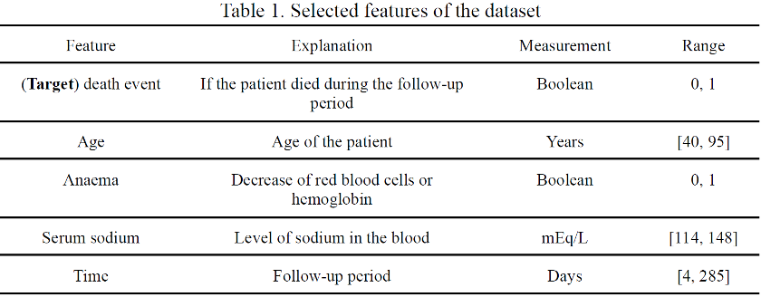

For the following sections, we use the original data set for exploratory data analysis because this way we could see the mean, variance, distributions, and other summary statistics of our interest more clearly. Instead, we standardize the non-bool variables when performing machine learning methods because different numerical features may have different means and variances such that they are not intuitively comparable with each other or not compatible with some statistical learning models.

### 2.1 Exploratory Data Analysis (EDA)

We are interested in the correlation between some predictors, such as age, serum_creatinine, and ejection_fraction, and DEATH_EVENT, the survival of patients, so we visualize their joint behaviors and calculate the correlation coefficients. We find that there is a weakly positive correlation between age and serum creatinine (i.e., 0.159), and the same is that between age and ejection fraction (i.e., 0.060). Instead, there is a relatively stronger and positive correlation between death and serum creatinine (i.e., 0.294). Also, the same is with that between death and ejection fraction whereas the correlation is negative (i.e., -0.269).

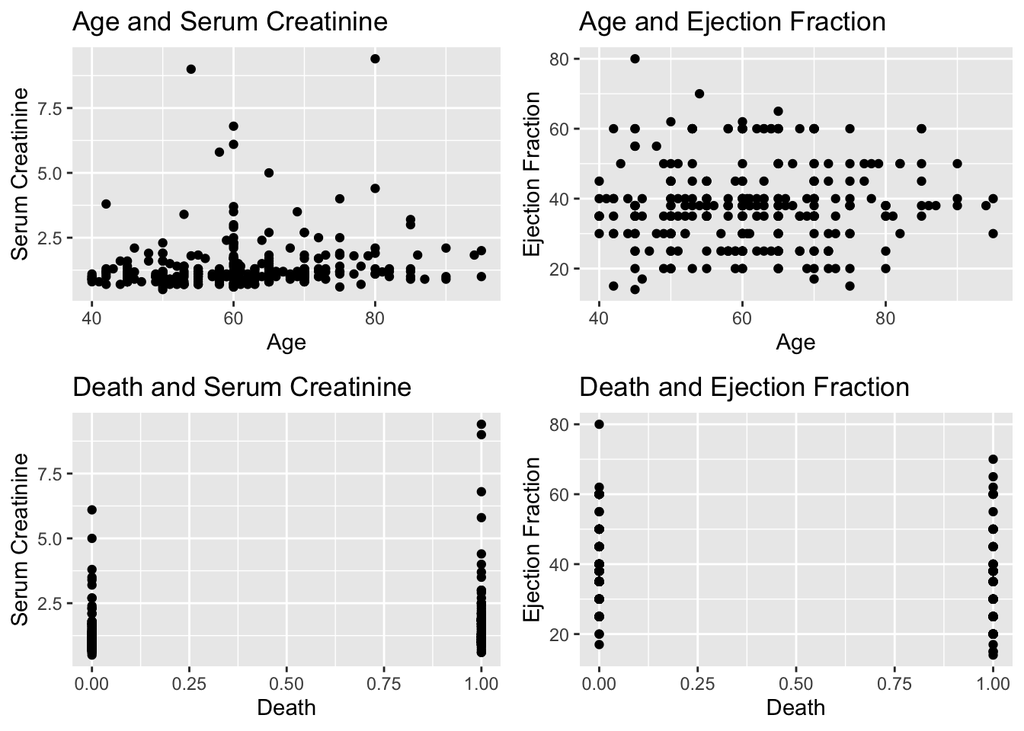

# 3 Learning Methods

### 3.1 Principal Components Analysis

We first try the unsupervised learning method, PCA, and we would like to know if we could find a low-dimensional representation of the observations. PCA projects the original high-dimensional data onto a low-dimensional space and make its variance as large as possible. If the value of a certain feature (a column of the matrix) of the data is particularly large, then it has a large proportion of the entire error calculation. Because we don’t know the importance of each feature before modeling, this is likely to lead to a large amount of information missing. For the sake of “fairness” and to prevent over-capturing certain features with large values, we will first standardize each feature so that their sizes are within the same range, and then perform PCA. From a computational point of view, another benefit of standardization before PCA is that this is beneficial to the gradient descent method of convergence. Because PCA is usually numerically approximated decomposition, rather than seeking eigenvalues, singular values to obtain analytical solutions, when we use gradient descent and other algorithms for PCA, we have to standardize the data first.

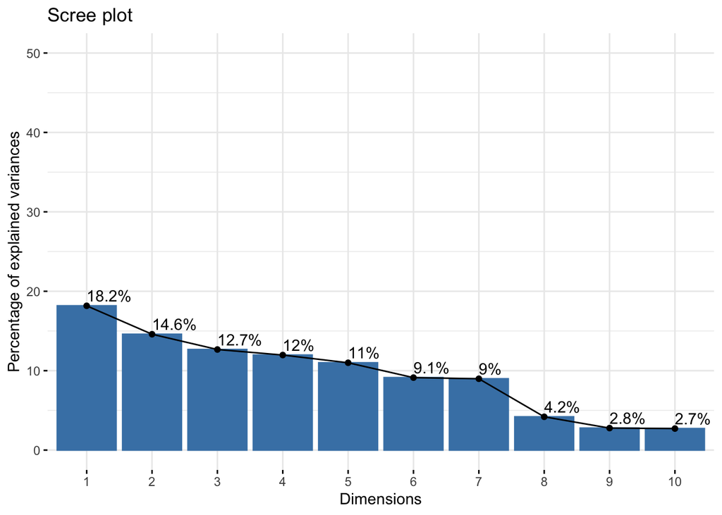

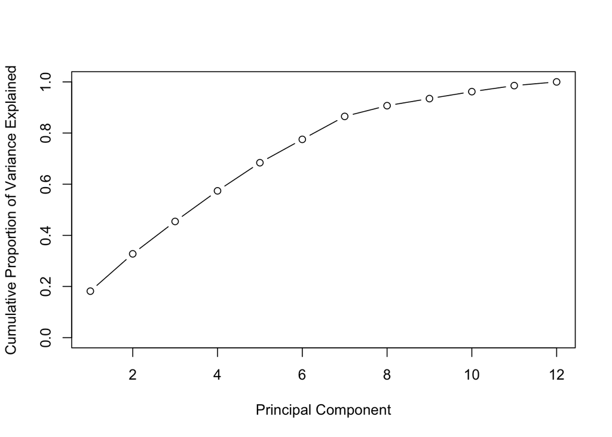

We find that seven principal components are required to explain at least 80% of the variation in the data, which is more than half of the PCs; and PC1’s variance percentage is only 18.57%, which is not really high. Based on this and the plot, it doesn’t seem like PCA has done a good job in reducing the dimensionality of the data.

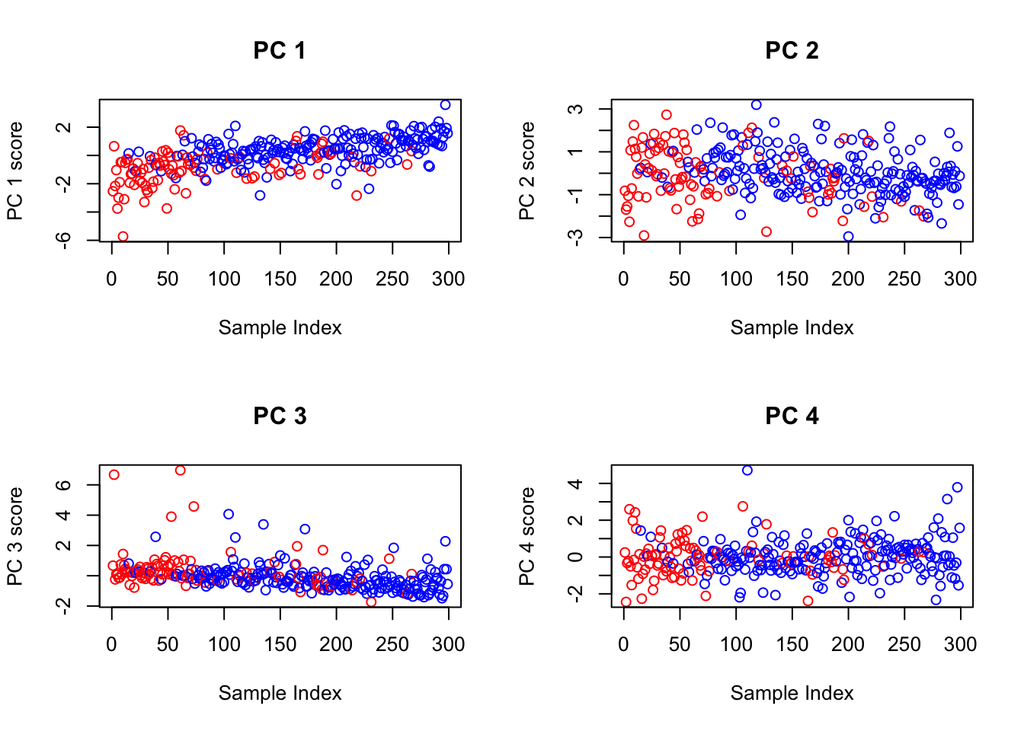

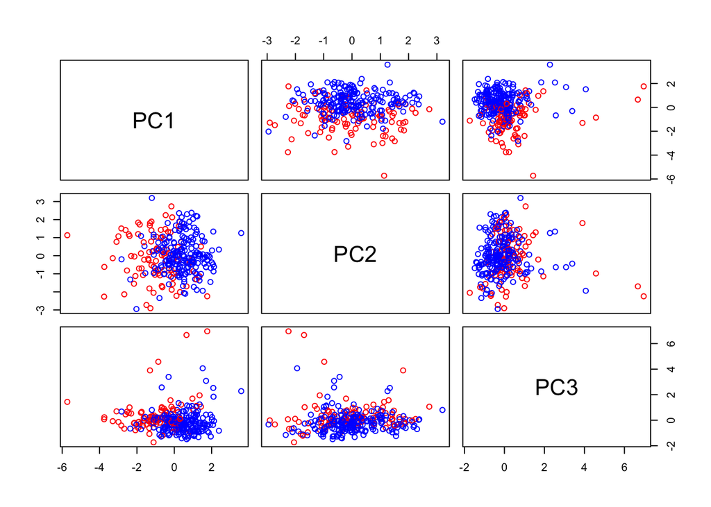

Plotting the PCs separately, there doesn’t seem to have any apparent clusters. All clusters seem to overlap on each other. However, After controlling for PC2 and PC3, dead patients in red seem to have lower PC1 than the patients alive. But there does not seem to be any clustering depending the levels of PC2 and PC3.

### 3.2 Clustering

Next, we perform a cluster analysis on the data.

We are interested in partitioning around medioids, self organizing maps. Intuitively, it means we could use K-means algorithm to classify the data into several different groups. Clustering is a method of unsupervised learning and the objects being clustered of course are the data points. It is quite useful for this data set because many features are binary so we just need to cluster the data points based on a limited number of features.

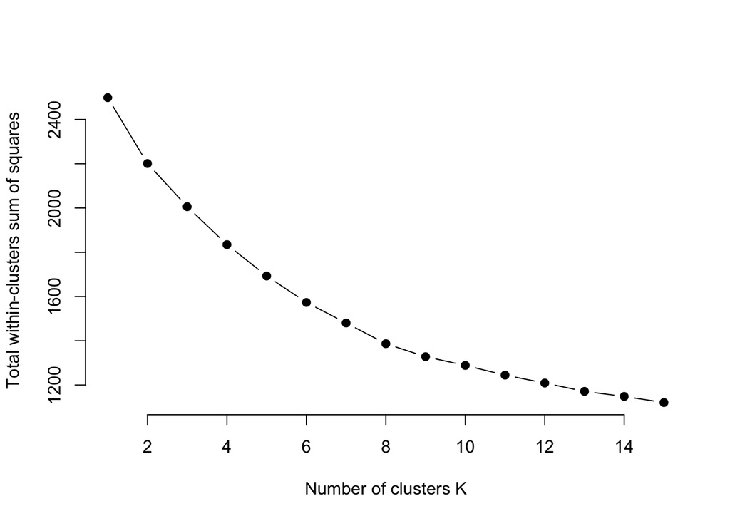

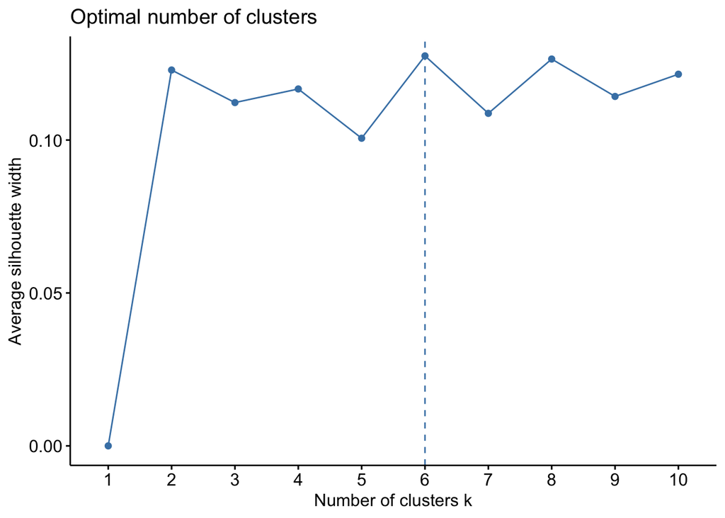

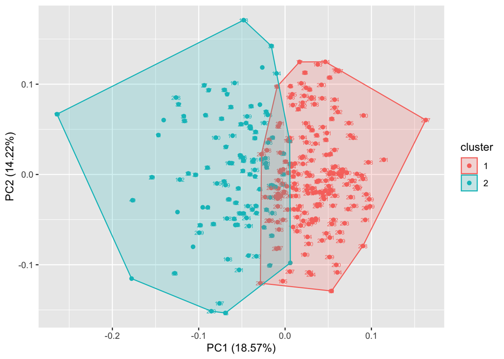

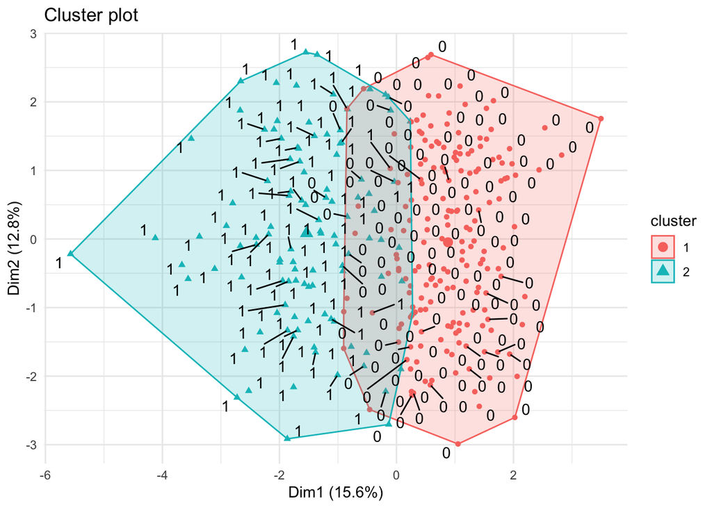

```
## # A tibble: 4 x 3
## # Groups:   cluster [2]
##   cluster class     n
##     <int> <int> <int>
## 1       1     0   175
## 2       1     1    15
## 3       2     0    28
## 4       2     1    81
```

### 3.3 Classification

Classification is simply the process in which one decides which class a new data point may fall into. A single object in the case of our dataset, is the set of survival results which are classified as either “0” or “1”. The variable that would be most interesting to predict is the “DEATH_EVENT” variable. This variable is either “0” or “1” in our dataset, indicating whether a patient has survived or not in their follow-up period. As stated before, predicting this variable can predict which subtype a set of measurements corresponds to results. For doing cross-validation in all classification methods in this section, we randomly break our data set into a training set (roughly 80% of the data) and a test set (roughly 20% of the data); ); while doing the 10-fold cross-validation, we randomly partition the data into 10 equal size subsamples, of the 10 subsamples, a single subsample is retained as the validation data for testing the model, and the remaining 9 subsamples are used as training data.

#### 3.3.1 K Nearest Neighbors

Then we apply the supervised learning method k-nearest neighbor (kNN) on our dataset. We choose kNN because of its easy of interpretation and low calculation time. Also, with the optimal k value, we can easily make a boundary of the two classes (dead or survived) that clearly segregates them from each other.

[output not shown]

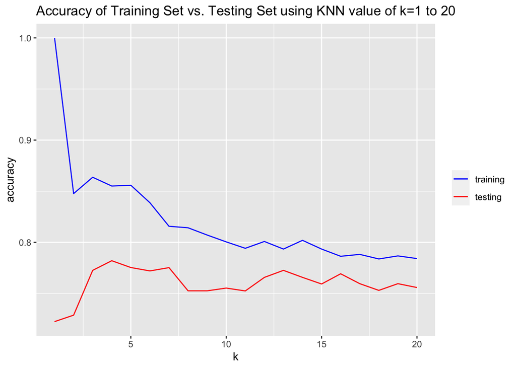

From the plot we could see that the accuracy reaches its first maxima when k = 4. Since we want k to be an odd number to avoid even vote, we segregate the training and validation from the initial dataset, apply 10-fold cross-validation on k = 3 and k = 5, plot the validation accuracy for each, and calculate the average accuracy.

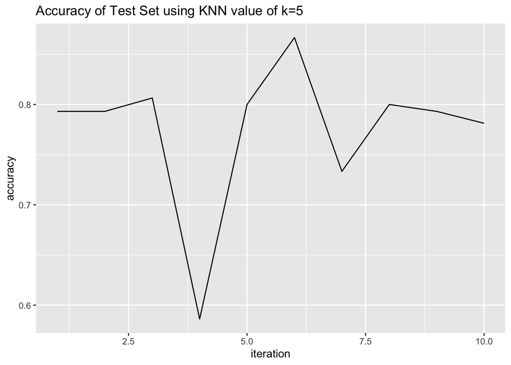

```
## [1] 0.7753219
```

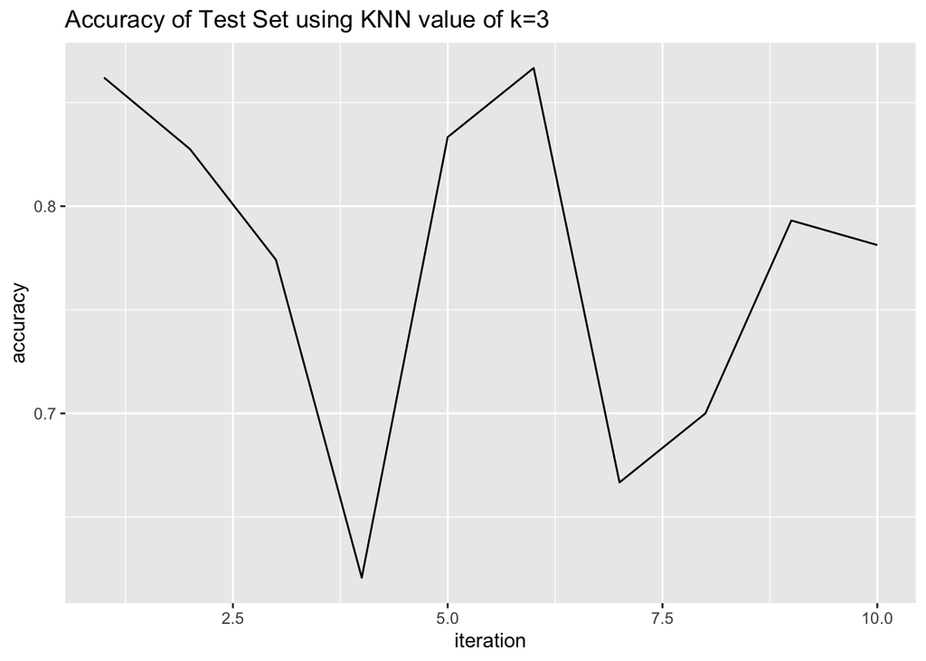

```
## [1] 0.7725558
```

From the calculated result, the optimal k value is 5 with the accuracy of 0.7753. This value of k should be used for all predictions.

#### 3.3.2 The Logistic Regression and LASSO

Since our predict target is a binary variable, and one of our goal is to find out which features are significant for the prediction, we then apply the logistic regression on our data set. Logistic regression model is easy to interpret, and all variables are in there, so we consider it as our baseline.

```
##
## Call:
## glm(formula = DEATH_EVENT ~ ., family = binomial, data = scale_heart.logi,
##     subset = train)
##
## Deviance Residuals:
##     Min       1Q   Median       3Q      Max
## -2.0510  -0.7559  -0.4778   0.8913   2.6557
##
## Coefficients:
##                           Estimate Std. Error z value Pr(>|z|)
## (Intercept)              -1.197451   0.399098  -3.000  0.00270 **
## age                       0.658037   0.167733   3.923 8.74e-05 ***
## creatinine_phosphokinase  0.143166   0.171856   0.833  0.40481
## ejection_fraction        -0.566296   0.185103  -3.059  0.00222 **
## platelets                -0.308396   0.192955  -1.598  0.10998
## serum_creatinine          0.495018   0.188036   2.633  0.00847 **
## serum_sodium             -0.388286   0.191921  -2.023  0.04306 *
## anaemia                   0.410482   0.325761   1.260  0.20764
## diabetes                 -0.008289   0.328848  -0.025  0.97989
## high_blood_pressure       0.499224   0.342861   1.456  0.14538
## sex                      -0.261777   0.396256  -0.661  0.50885
## smoking                   0.208883   0.380170   0.549  0.58270
## ---
## Signif. codes:  0 '***' 0.001 '**' 0.01 '*' 0.05 '.' 0.1 ' ' 1
##
## (Dispersion parameter for binomial family taken to be 1)
##
##     Null deviance: 301.89  on 238  degrees of freedom
## Residual deviance: 242.93  on 227  degrees of freedom
## AIC: 266.93
##
## Number of Fisher Scoring iterations: 5
```

```
## [1] 0.75
```

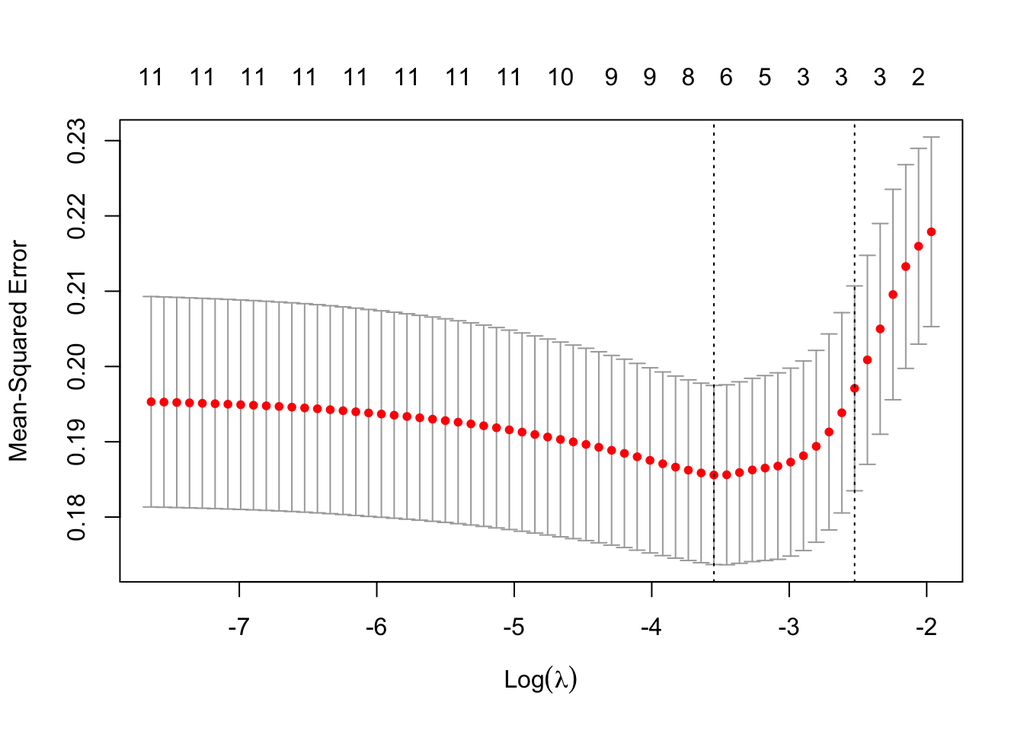

```
## [1] 0.02878973
```

```
## [1] 0.1905741
```

```
## 12 x 1 sparse Matrix of class "dgCMatrix"
##                                   s0
## (Intercept)               0.31742208
## age                       0.08009002
## creatinine_phosphokinase  0.00614508
## ejection_fraction        -0.09596062
## platelets                 .
## serum_creatinine          0.09028105
## serum_sodium             -0.02537043
## anaemia                   .
## diabetes                  .
## high_blood_pressure       0.01038856
## sex                       .
## smoking                   .
```

Next, we use Least Absolute Shrinkage and Selection Operator (LASSO) to help us select the most important features to better predict the survival of patients in a linear setting. We find that only six variables with high statistical significance and large magnitude are left after the model’s selection: age, creatinine_phosphokinase, ejection_fraction, serum_creatinine, serum_sodium, and high_blood_pressure. Among them, the coefficients of age, ejection_fraction, and serum_creatinine have the largest magnitude. This result validates what we have discovered from the baseline.

#### 3.3.3 Decision Trees

The final classification method we use is decision trees, because it is a white box model that is easy to understand and interpret. Also, it can potentially judge our previous results. We fit the whole data set on the basic tree, do cross-validation, and finally create a pruned tree to improve the performance.

```
##
## Classification tree:
## tree(formula = death ~ . - DEATH_EVENT - time - sex, data = scale_heart_temp)
## Variables actually used in tree construction:
## [1] "serum_creatinine"         "ejection_fraction"
## [3] "serum_sodium"             "age"
## [5] "creatinine_phosphokinase"
## Number of terminal nodes:  11
## Residual mean deviance:  0.8297 = 238.9 / 288
## Misclassification error rate: 0.1773 = 53 / 299
```

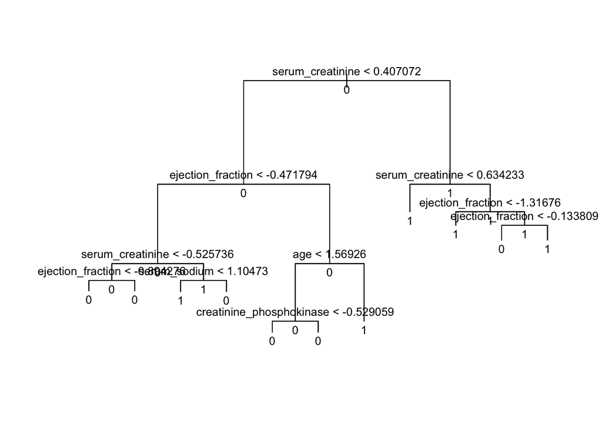

```
##             death.test
## tree.predict  1  0
##            1 11  8
##            0  7 34
```

In order to properly evaluate the performance of this classification tree on the data, we must estimate the test error rather than simply computing the training error. Hence, we split our data into a training set and a test set. This approach, leads to correct predictions for around 75% of the data points in the test data set.

```
## [1] "size"   "dev"    "k"      "method"
```

```
## $size
## [1] 11  9  6  2  1
##
## $dev
## [1] 83 82 77 83 98
##
## $k
## [1]      -Inf  0.000000  1.666667  4.000000 22.000000
##
## $method
## [1] "misclass"
##
## attr(,"class")
## [1] "prune"         "tree.sequence"
```

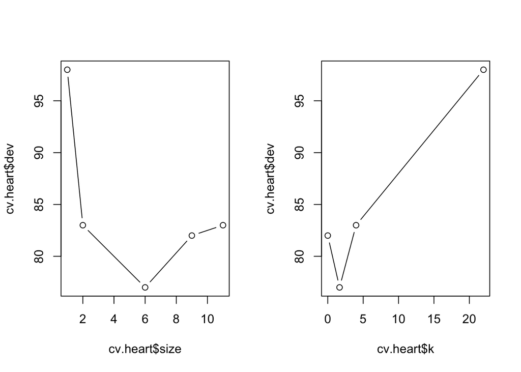

```
##                death.test
## tree.heart.pred  1  0
##               1 16 10
##               0  2 32
```

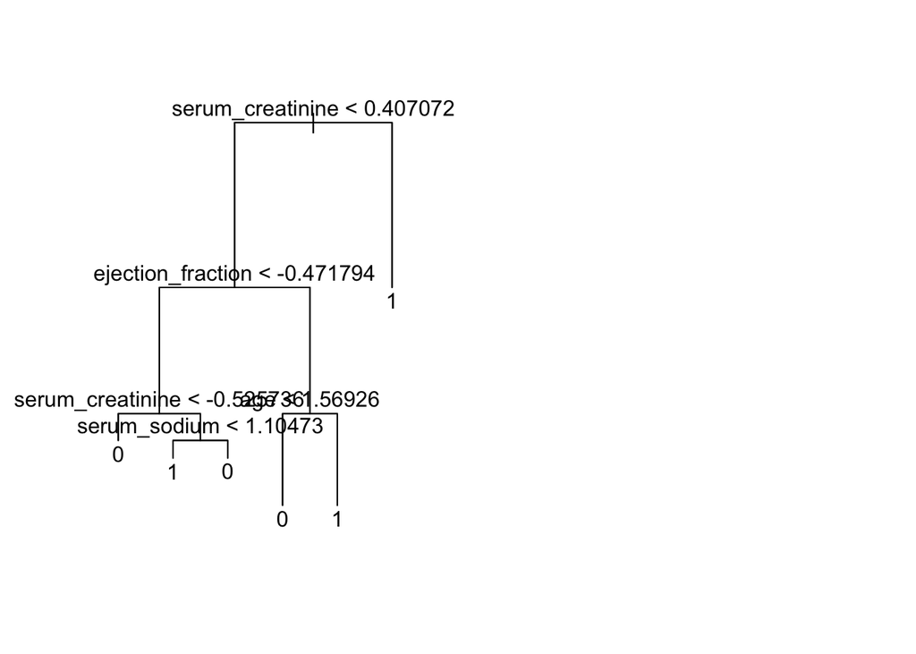

Finally, we consider whether pruning the tree might lead to improved results. To start off, we perform cross-validation in order to determine the optimal level of tree complexity, and we do cost complexity pruning to select a sequence of trees for consideration. From the plot, we observe that the tree with 6 terminal nodes has the lowest cross-validation error rate, with 77 cross-validation errors. Next, we prune the tree to obtain the six-node tree. We find that now 80% of the observations are correctly classified, and there are only four predictors remained in our pruned tree: serum_creatinine, ejection fraction, serum sodium, and age. This resulting pruned tree also validates our base-line result that regards serum_creatinine and ejection fraction as two most important predictors. To sum up, the pruning process produces a more interpretable tree, and it also improves the classification accuracy.